# Xbox Game Pass Analysis

### Author: Anh Ngo Le Duy

### Github: AnhNgo2803

### Github Repository: xbox-game-pass-analysis

*This project uses '*Enhanced_Gamepass_Games_v2*' dataset published by [Rohan](https://www.kaggle.com/datasets/vines666/enhanced-xbox-game-pass-genres) in Kaggle platform.*

# Excutive summary

- This data analysis project examines the Xbox Game Pass dataset ('Enhanced_Gamepass_Games_v2' from Kaggle), comprising 455 games, to uncover factors influencing game popularity, completion rates, and ratings. The objective is to deliver actionable insights for game developers, enabling them to enhance user experiences and optimize gameplay strategies on the platform.
- Utilizing Python libraries such as Pandas, NumPy, Seaborn, Matplotlib, and Scikit-learn, the analysis began with comprehensive data preparation: inspecting structures, handling missing values (using mode for categorical and mean for numerical data), converting formats (e.g., time ranges to numerical averages), and dropping non-essential columns. Exploratory data analysis focused on genre preferences, revealing Sandbox, Compilation, and MMO as the most popular genres based on average gamers (247,504; 181,648; and 133,438 respectively). Visualization techniques, including bar charts and bubble plots, highlighted two success models: High-Engagement (long playtimes in MMO and Compilation, fostering deep immersion and community) and Mass-Appeal (short, creative experiences in Sandbox, attracting broad audiences).
- Further, K-means clustering on difficulty ratio and playtime classified games into four distinct types: Casual (easy-short), Epic (hard-very long), Challenge (very hard-short), and Mainstream (hard-long). Cross-tabulation and stacked bar charts showed Casual dominating with diverse genres like Action and Adventure, while Epic offers untapped potential with high gamer averages but limited variety. Key insights indicate that popularity stems from engagement depth or accessibility rather than completion rates. Recommendations include prioritizing multiplayer features and narrative depth for loyal communities (e.g., MMO/RPG), while emphasizing creativity and freedom for mass appeal (e.g., Sandbox). This approach can guide Xbox developers in resource allocation, genre diversification, and user-centric design, ultimately boosting retention and acquisition.
- Skills demonstrated: Data cleaning, statistical analysis, visualization, unsupervised machine learning, and insight derivation for business impact.

# Problem statement

The goal of this project is to analyze the dataset for uncovering factors that affect the popularity, completion rate, and ratings of games. As a result, provide useful insights for game developers to optimize gaming experience.

## Main section

1. Data preparation
2. Genre analysis
3. Difficulty and play time analysis
4. Conclusion

# Data preparation

## Data inspection

```python
# import essential library
import pandas as pd
import numpy as np
import seaborn as sns
import matplotlib.pyplot as plt
```

```python
# call the dataset
game = pd.read_csv('Enhanced_Gamepass_Games_v2.csv')
```

```python
# briefly inspect structure
game.info()
```

```
<class 'pandas.core.frame.DataFrame'>
RangeIndex: 455 entries, 0 to 454
Data columns (total 15 columns):
 #   Column            Non-Null Count  Dtype
---  ------            --------------  -----
 0   GAME              455 non-null    object
 1   RATIO             455 non-null    object
 2   GAMERS            455 non-null    object
 3   COMP %            455 non-null    float64
 4   TIME              421 non-null    object
 5   RATING            452 non-null    float64
 6   ADDED             454 non-null    object
 7   True_Achievement  455 non-null    int64
 8   Game_Score        455 non-null    int64
 9   GENRES            453 non-null    object
 10  Main_Genre        453 non-null    object
 11  second_genre      452 non-null    object
 12  third_genre       350 non-null    object
 13  fourth_genre      5 non-null      object
 14  name_genre_match  453 non-null    object
dtypes: float64(2), int64(2), object(11)
memory usage: 53.4+ KB
```

```python
# inspect data in first rows of data set
game.head()
```

|  | GAME | RATIO | GAMERS | COMP % | TIME | RATING | ADDED | True_Achievement | Game_Score | GENRES | Main_Genre | second_genre | third_genre | fourth_genre | name_genre_match |
| --- | --- | --- | --- | --- | --- | --- | --- | --- | --- | --- | --- | --- | --- | --- | --- |
| 0 | Mass Effect Legendary Edition | 1.87 | 84,143 | 4.1 | 100-120 hours | 4.8 | 06 Jan 22 | 5442 | 2915 | Action, RPG, Third-Person Shooter | Action | RPG | Third-Person Shooter | NaN | Mass Effect Legendary Edition |
| 1 | The Elder Scrolls V: Skyrim Special Edition | 1.97 | 213,257 | 8.0 | 80-100 hours | 4.7 | 15 Dec 20 | 3055 | 1550 | RPG, Action, Adventure, Open World | RPG | Action | Adventure | Open World | The Elder Scrolls V: Skyrim Special Edition |
| 2 | Mass Effect 2 | 1.34 | 221,178 | 9.6 | 50-60 hours | 4.7 | 09 Nov 20 | 1819 | 1355 | Action, RPG, Third-Person Shooter | Action | RPG | Third-Person Shooter | NaN | Mass Effect 2 |
| 3 | Stardew Valley | 3.04 | 51,530 | 1.0 | 150-200 hours | 4.7 | 02 Dec 21 | 3036 | 1000 | Simulation, RPG, Indie, Farming Sim | Simulation | RPG | Indie | Farming Sim | Stardew Valley |
| 4 | It Takes Two | 1.68 | 71,981 | 15.6 | 12-15 hours | 4.7 | 03 Nov 21 | 1678 | 1000 | Action, Adventure, Platformer, Co-op | Action | Adventure | Platformer | Co-op | It Takes Two |

## Data manipulation

Through data structure and its corresponding values, there are variables that need to be adjusted to correct formats.

**Deal with categorical data**

```python
# change data type to categorical data
game_new = game.copy() # create a copy of original data

game_new[['GAME','Main_Genre','second_genre','third_genre','fourth_genre','name_genre_match']] = game_new[
    ['GAME','Main_Genre','second_genre','third_genre','fourth_genre','name_genre_match']].astype('category')

game_new[['GAME','Main_Genre','second_genre','third_genre','fourth_genre','name_genre_match']].dtypes # check again
```

```
GAME                category
Main_Genre          category
second_genre        category
third_genre         category
fourth_genre        category
name_genre_match    category
dtype: object
```

```python
# since the ratio column realize '-' in values, I inspect and remove it before changing data type
game_new.groupby('RATIO')['RATIO'].agg('count').head()
```

```
RATIO
-       3
1.04    1
1.06    1
1.1     1
1.13    1
Name: RATIO, dtype: int64
```

```python
# RATIO colum
game_new['RATIO'] = game_new['RATIO'].replace('-',np.nan).astype('float64')

# GAMERS column
game_new['GAMERS'] = game_new['GAMERS'].str.replace(',','').astype('int64')

# check result
game_new[['GAMERS','RATIO']].dtypes
```

```
GAMERS      int64
RATIO     float64
dtype: object
```

**Deal with Time data (from categorical to number)**

```python
# inspect the values in time column
game_new.groupby('TIME')['TIME'].value_counts(dropna= False) # Na included
```

```
TIME
0-0.5 hours       1
0.5-1 hour        1
1-2 hours        17
10-12 hours      12
100-120 hours     9
1000+ hours       5
12-15 hours      15
120-150 hours     3
15-20 hours      31
150-200 hours    19
2-3 hours        11
20-25 hours      36
200-300 hours     7
25-30 hours      30
3-4 hours        11
30-35 hours      10
300-500 hours     3
35-40 hours       4
4-5 hours         7
40-50 hours      39
5-6 hours         5
50-60 hours      24
500-750 hours     1
6-8 hours        20
60-80 hours      42
8-10 hours       27
80-100 hours     31
Name: count, dtype: int64
```

For easier for analysis later, I added a column that take the mean of time frames in time column, except the "1000+ hours" data, which will be maintained as 1000.

```python
# replace the words "hours" in new column
game_new['time_num'] = game_new['TIME'].str.replace(r' hours|hour','', regex=True)

# define a function
def time_convert(value):
    value = str(value)
    if "+" in value:
       x = value.replace("+","") # remove "+" for "1000+" cases
       return np.int64(x) # change data type
    else:
        x = value.split("-") # from "40-60" to ["40","60"]
        num = list(map(float,x)) # map func float to each value and change to list
        return np.mean(num) # calculate the mean

# apply function for each row in new column
game_new['time_num'] = game_new['time_num'].apply(time_convert)

# compare 2 columns (categorical vs numeric data)
print(game_new[['TIME','time_num']])
```

```
              TIME  time_num
0    100-120 hours     110.0
1     80-100 hours      90.0
2      50-60 hours      55.0
3    150-200 hours     175.0
4      12-15 hours      13.5
..             ...       ...
450    15-20 hours      17.5
451            NaN       NaN
452            NaN       NaN
453            NaN       NaN
454            NaN       NaN

[455 rows x 2 columns]
```

**Deal with Na values**

```python
# inspect Na in each column
x = game_new.isnull().sum().sort_values(ascending=False)

print(x)
```

```
fourth_genre        450
third_genre         105
TIME                 34
time_num             34
RATIO                 3
RATING                3
second_genre          3
GENRES                2
Main_Genre            2
name_genre_match      2
ADDED                 1
GAME                  0
GAMERS                0
COMP %                0
True_Achievement      0
Game_Score            0
dtype: int64
```

Even though fourth and third genre column have the most na values among other variables, I did not process those variables, instead, I chose to eliminate these colomns since it's not highly essential for the analysis target.

```python
# remove fourth and third genre column
game_new = game_new.drop(['fourth_genre','third_genre'], axis=1) # eliminate assigned coloumns
```

**Handle Na values**

- With categorical data such as `TIME`, `second_genre`, `GENRES`, `Main_Genre`, `name_genre_match`, and `ADDED` (Time data), I used *mode* method to fill those Na values
- With continuos data such as `RATIO`, `RATING`, and `time_num`, I used *mean* method to fill those values.

```python
# fill Na values of categorical and text data
cate_cols = ['TIME','second_genre','GENRES','Main_Genre', 'name_genre_match','ADDED']

# create for loop for automatically repeat process
for col in cate_cols:
    mode_val = game_new[col].mode()[0]
    game_new[col] = game_new[col].fillna(mode_val)
```

```python
# fill Na values of numeric data
num_cols = ['RATIO','RATING','time_num']

# create for loop for automatically repeat process
for col in num_cols:
    mean_val = np.mean(game_new[col])
    game_new[col] = game_new[col].fillna(mean_val)
```

```python
# check Na again
x = game_new.isnull().sum().sort_values(ascending=False)

print(x)
```

```
GAME                0
RATIO               0
GAMERS              0
COMP %              0
TIME                0
RATING              0
ADDED               0
True_Achievement    0
Game_Score          0
GENRES              0
Main_Genre          0
second_genre        0
name_genre_match    0
time_num            0
dtype: int64
```

# Genre analysis

In this section, I want to determine what are genres that gamers prefer most compared to the others. From that, finding features of those popular games to have a transparent model about a successful game, which enhances developing strategies for game developers in Xbox pass product.

```python
game_new.info() # recall the structure and columns
```

```
<class 'pandas.core.frame.DataFrame'>
RangeIndex: 455 entries, 0 to 454
Data columns (total 14 columns):
 #   Column            Non-Null Count  Dtype
---  ------            --------------  -----
 0   GAME              455 non-null    category
 1   RATIO             455 non-null    float64
 2   GAMERS            455 non-null    int64
 3   COMP %            455 non-null    float64
 4   TIME              455 non-null    object
 5   RATING            455 non-null    float64
 6   ADDED             455 non-null    object
 7   True_Achievement  455 non-null    int64
 8   Game_Score        455 non-null    int64
 9   GENRES            455 non-null    object
 10  Main_Genre        455 non-null    category
 11  second_genre      455 non-null    category
 12  name_genre_match  455 non-null    category
 13  time_num          455 non-null    float64
dtypes: category(4), float64(4), int64(3), object(3)
memory usage: 80.9+ KB
```

```python
genre_ana = game_new.groupby('Main_Genre').agg(
    gamer = pd.NamedAgg(column = "GAMERS", aggfunc= "mean"),
    rating = pd.NamedAgg(column = "RATING", aggfunc= "mean"),
    comp_ratio = pd.NamedAgg(column = "COMP %", aggfunc= "mean"),
    play_time = pd.NamedAgg(column= "time_num", aggfunc = "mean")
).round(2).sort_values(by='gamer', ascending=False)
genre_ana
```

| Main_Genre | gamer | rating | comp_ratio | play_time |
| --- | --- | --- | --- | --- |
| Sandbox | 247504.50 | 4.10 | 1.10 | 61.25 |
| Compilation | 181648.00 | 4.20 | 0.20 | 250.00 |
| MMO | 133438.00 | 3.65 | 0.45 | 812.50 |
| Action | 108350.51 | 3.74 | 4.38 | 60.93 |
| Platformer | 100755.00 | 4.17 | 7.98 | 16.00 |
| Survival Horror | 93950.64 | 4.16 | 4.75 | 35.62 |
| Racing | 91995.09 | 3.69 | 2.67 | 54.46 |
| RPG | 86764.84 | 3.89 | 4.23 | 66.16 |
| Party Game | 79755.00 | 3.70 | 2.10 | 4.50 |
| Fighting | 79038.62 | 3.76 | 2.84 | 58.96 |
| Puzzle | 66289.00 | 3.43 | 3.73 | 67.70 |
| Arcade | 65801.50 | 3.05 | 10.95 | 10.00 |
| Sports | 54538.18 | 3.37 | 1.59 | 55.53 |
| Simulation | 54124.59 | 3.46 | 6.41 | 104.37 |
| Metroidvania | 52927.00 | 4.50 | 1.00 | 70.00 |
| Adventure | 52584.51 | 3.62 | 18.36 | 30.11 |
| Rhythm | 43721.00 | 3.90 | 1.10 | 55.00 |
| Roguelike | 37695.12 | 3.92 | 0.85 | 73.75 |
| Strategy | 30667.16 | 3.63 | 1.06 | 63.96 |

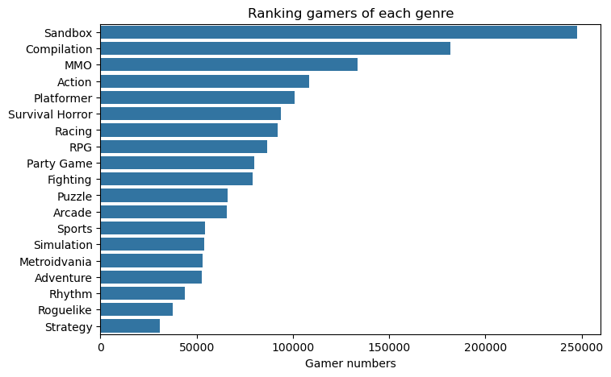

```python
# visualize the number of gamers of each genre
plt.figure(figsize=(8,5))
f1 = sns.barplot(genre_ana, x="gamer", y="Main_Genre", orient="y", order = genre_ana.index)
f1.set_title("Ranking gamers of each genre")
f1.set_ylabel("")
f1.set_xlabel("Gamer numbers")
plt.show()
```

### Initial analysis

Thus, I dived into these differences among top ranked genres by using bubble chart, which shows the relationship between gamers, completion ratio, and playing duration.

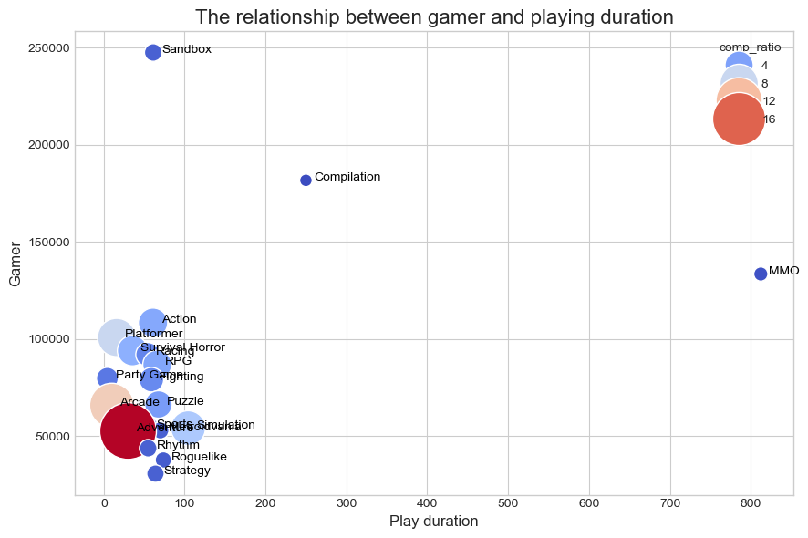

```python
# create a bubble chart
plt.figure(figsize=(9,6))
f2 = sns.scatterplot(data = genre_ana,
                     y = "gamer",
                     x = "play_time",
                     size = "comp_ratio",
                     hue="comp_ratio",
                     sizes=(100,2000),
                     palette="coolwarm")

# set the legend for each genre in chart
for genre in genre_ana.index:
    plt.text(x = genre_ana.loc[genre,'play_time'] + 10,
             y = genre_ana.loc[genre, 'gamer'] - 100,
             s = genre,
             fontdict= dict(color="black", size=10))

# set title and legend
plt.title("The relationship between gamer and playing duration", fontsize=16)
plt.xlabel("Play duration", fontsize = 12)
plt.ylabel("Gamer", fontsize = 12)

plt.grid(True)
plt.tight_layout()
plt.show()
```

### Insight

Our analysis reveals that popular game genres on Xbox Game Pass achieve success through two distinct models: **building a high-engagement community** and **attracting a mass-appeal audience.**

- The High-Engagement Model (MMO & Compilation): These genres have large number of players with long gaming duration. In other words, with these genres, gamers tend to invest more time in experiencing and exploring games. Moreover, with MMO, a genre whose game focuses on online multiple player, it also strengthens to the fact that people love player connection experience, which makes them spend more time in gaming. Meanwhile, Compilation genre concentrates on experiencing a game with extended versions or stories, which arouses the curiorsity of gamers to make them spend more time in games.
- The Mass-Appeal Model (Sandbox): This genre appriciates the creativity of players instead of building complex stories inside. In contrast to long average playtime as MMO and Compilation, Sandbox though has a short playing duration, it still obtains advocates from gamers thanks for its emphasize on freedom, creativity, and accessible gameplay. This suggests that games prioritizing freedom and creativity are highly effective in appealing to a wider, more general audience compared to other gameplay styles.

**Conclusion & Recommendation:** Notably, **completion ratio** is not a primary driver of popularity for these top-tier genres. Success is determined by the mode of engagement—either deep retention or broad appeal. Consequently, Xbox game developers should focus on crafting innovative gameplay experiences and investing in multiplayer enhancements. This dual approach can help sustain a loyal gaming community while also attracting new players with fresh game offerings.

# Difficulty and Playtime Analysis

In this part, I want to focus on the gaming experience of gamers, particularly in the achievement difficulty of genres compared to true score from players. Therefore, I used `RATIO` and `time_num` columns to inspect this problem.

```python
# recall the data information
game_new.info()
```

```
<class 'pandas.core.frame.DataFrame'>
RangeIndex: 455 entries, 0 to 454
Data columns (total 14 columns):
 #   Column            Non-Null Count  Dtype
---  ------            --------------  -----
 0   GAME              455 non-null    category
 1   RATIO             455 non-null    float64
 2   GAMERS            455 non-null    int64
 3   COMP %            455 non-null    float64
 4   TIME              455 non-null    object
 5   RATING            455 non-null    float64
 6   ADDED             455 non-null    object
 7   True_Achievement  455 non-null    int64
 8   Game_Score        455 non-null    int64
 9   GENRES            455 non-null    object
 10  Main_Genre        455 non-null    category
 11  second_genre      455 non-null    category
 12  name_genre_match  455 non-null    category
 13  time_num          455 non-null    float64
dtypes: category(4), float64(4), int64(3), object(3)
memory usage: 80.9+ KB
```

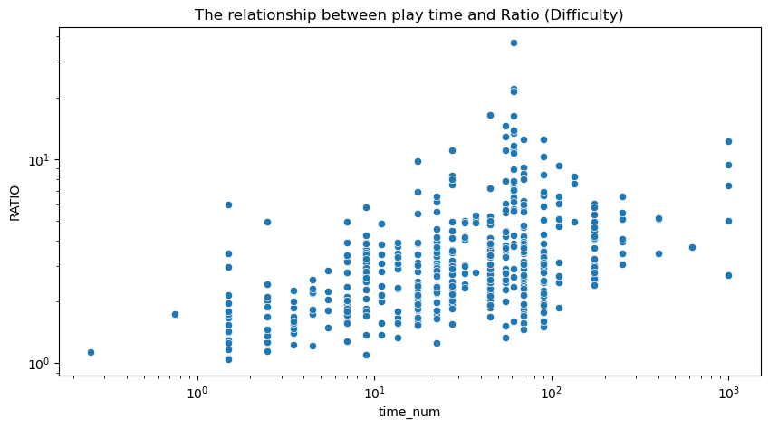

```python
plt.figure(figsize=(10,5))
sns.scatterplot(data = game_new, y="RATIO", x="time_num")
plt.title("The relationship between play time and Ratio (Difficulty)")
plt.xscale('log')
plt.yscale('log')
plt.show()
```

**Brief decription**

In the code above, since values are distributed mostly around low play time and ratio, with a few of long play time and high ratio data. Thus, I transfered two variables to logarit to expand data in low range and narrow the data in high range.

### Apply K-means clusterring for better classification

From the scatter plot, it can be seen that games may be divided into clusters with different features, instead of having a linear relationship. However, common observation is objective, which is consequently essential to have an unsupervised machine learning, k-means clustering. The final target is to determine whether the model can classify these clusters as innitally predicted or not.

```python
# import model
from sklearn.cluster import KMeans
from sklearn.preprocessing import StandardScaler
```

```python
# extract and standardize variables for model
km_va = game_new[['RATIO','time_num']]

scaler = StandardScaler()
km_scaled = pd.DataFrame(
    scaler.fit_transform(km_va), # data scaled (numpy array)
    columns = km_va.columns
)
```

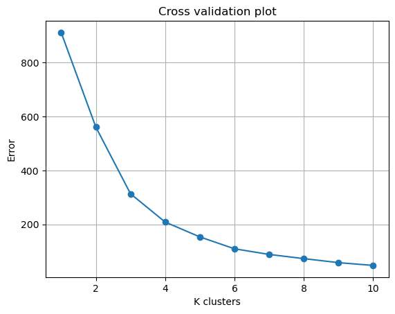

```python
# Run k-means model with cross validation
inertia = []
K = range(1,11)

for k in K:
    k_mdl = KMeans(n_clusters=k, n_init=20, max_iter= 100, random_state= 42)
    k_mdl.fit(km_scaled)
    inertia.append(k_mdl.inertia_)

# Cross validation plot
plt.plot(K,inertia, marker="o")
plt.xlabel("K clusters")
plt.ylabel("Error")
plt.title("Cross validation plot")
plt.grid(True)
plt.show()
```

**Optimal km mean cluster**

From the plot above, k cluster at point 4 shows the kink of error. Following the "elbow method", I choose 4 as an optimal k cluster for the model.

```python
# run again the model
km_mdl = KMeans(n_clusters = 4, n_init=20, max_iter=100, random_state=42)
mdl_fit = km_mdl.fit(km_scaled)
```

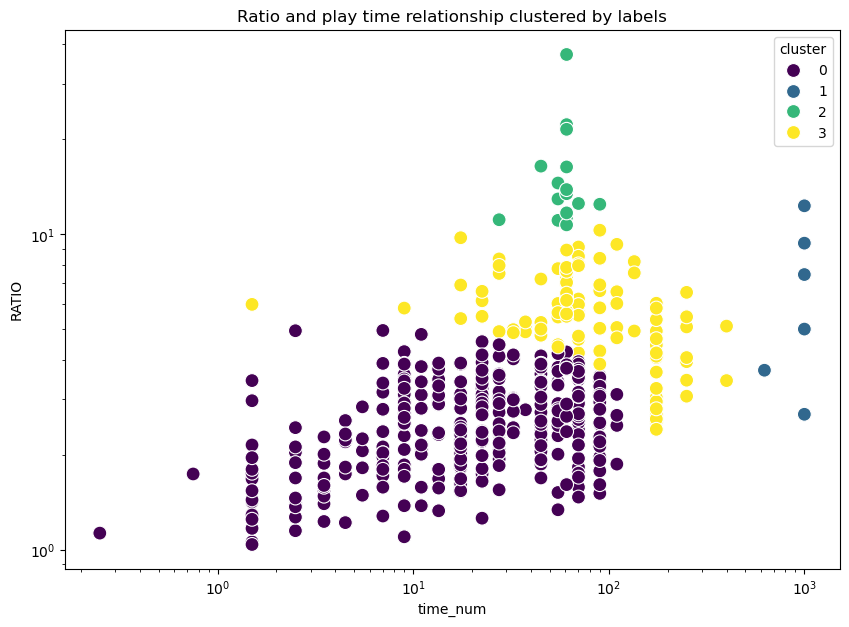

```python
# add a column containing labels of cluster
km_va['cluster'] = mdl_fit.labels_

# visualize scatter plot using logarit, and coloring data point by cluster label
plt.figure(figsize= (10,7))
sns.scatterplot(data = km_va,
                y= 'RATIO',
                x= 'time_num',
                hue='cluster',
                palette='viridis', s=100)
plt.xscale("log")
plt.yscale("log")
plt.title("Ratio and play time relationship clustered by labels")
plt.show()
```

```python
# create the mean of RATIO and time_num by clusters
summary_km = km_va.groupby('cluster').agg(RATIO = pd.NamedAgg(column="RATIO", aggfunc= "mean"),
                             time_num = pd.NamedAgg(column="time_num",aggfunc="mean")).round(2)
summary_km
```

| cluster | RATIO | time_num |
| --- | --- | --- |
| 0 | 2.56 | 31.29 |
| 1 | 6.76 | 937.50 |
| 2 | 15.60 | 59.08 |
| 3 | 5.69 | 107.01 |

### Analysis

Based on the scatter plot colored by clusters and summary of RATIO and play time mean by clusters, the data points are divided into 4 clusters with clear features:

- Cluster 0 (Easy - short): Casual games, conveniently entertaining for common players.
- Cluster 1 (Hard - very long): Triple A games, require players to invest in playing time for exploring sufficient games.
- Cluster 2 (Very Hard - short): Intelligence concentration, which is suitable for players who does not have much time.
- Cluster 3 (Hard - Long): Long-term games, which make gamers spend long time to play for understanding gameplays.

## Extended problem

From the genre analysis and this result, I have raised a question that even though players in Xbox game pass prefer high-engagement and mass appeal gameplays, what genres do gamers prefer to play within these 4 features?

```python
# join the cluster into the game_new df
joined_df = game_new.join(km_va['cluster'])

# add name for clusters
cluster_name = {
    0: 'Casual (easy-short)',
    1: 'Epic (hard-very long)',
    2: 'Challenge (very hard-short)',
    3: 'Mainstream (hard-long)'
}

# map the name with corresponding cluster in df
joined_df['Cluster name'] = joined_df['cluster'].map(cluster_name)
```

```python
# group gamers count by each game type
gamer_vs_type = (
joined_df
    .groupby(['Cluster name','Main_Genre'])
    .agg(total_gamer = pd.NamedAgg(column = 'GAMERS', aggfunc='mean'))
    .unstack(level='Main_Genre')
    .fillna(0)
    .round(0)
# unstack second index into a new column
# instead of NaN, 0 will be filled for cases of Main Genre have 0 players
)
gamer_vs_type
```

| Main_Genre Cluster name | total_gamer Action | total_gamer Adventure | total_gamer Arcade | total_gamer Compilation | total_gamer Fighting | total_gamer MMO | total_gamer Metroidvania | total_gamer Party Game | total_gamer Platformer | total_gamer Puzzle | total_gamer RPG | total_gamer Racing | total_gamer Rhythm | total_gamer Roguelike | total_gamer Sandbox | total_gamer Simulation | total_gamer Sports | total_gamer Strategy | total_gamer Survival Horror |
| --- | --- | --- | --- | --- | --- | --- | --- | --- | --- | --- | --- | --- | --- | --- | --- | --- | --- | --- | --- |
| Casual (easy-short) | 106602.0 | 49776.0 | 65802.0 | 0.0 | 75022.0 | 0.0 | 0.0 | 79755.0 | 100755.0 | 77024.0 | 108377.0 | 98806.0 | 0.0 | 16668.0 | 247504.0 | 49042.0 | 49182.0 | 42522.0 | 99812.0 |
| Challenge (very hard-short) | 7575.0 | 50156.0 | 0.0 | 0.0 | 0.0 | 0.0 | 0.0 | 0.0 | 0.0 | 0.0 | 0.0 | 89907.0 | 0.0 | 27710.0 | 0.0 | 29942.0 | 84000.0 | 11810.0 | 0.0 |
| Epic (hard-very long) | 345603.0 | 344597.0 | 0.0 | 0.0 | 0.0 | 133438.0 | 0.0 | 0.0 | 0.0 | 0.0 | 0.0 | 0.0 | 0.0 | 0.0 | 0.0 | 91677.0 | 0.0 | 0.0 | 0.0 |
| Mainstream (hard-long) | 110627.0 | 29242.0 | 0.0 | 181648.0 | 85733.0 | 0.0 | 52927.0 | 0.0 | 0.0 | 50186.0 | 19965.0 | 61867.0 | 43721.0 | 48103.0 | 0.0 | 63292.0 | 60697.0 | 29723.0 | 35332.0 |

```python
# create a summary table of genre options across 4 game types
crosstab = pd.crosstab(joined_df['Cluster name'],joined_df['Main_Genre'])
crosstab
```

| Main_Genre Cluster name | Action | Adventure | Arcade | Compilation | Fighting | MMO | Metroidvania | Party Game | Platformer | Puzzle | RPG | Racing | Rhythm | Roguelike | Sandbox | Simulation | Sports | Strategy | Survival Horror |
| --- | --- | --- | --- | --- | --- | --- | --- | --- | --- | --- | --- | --- | --- | --- | --- | --- | --- | --- | --- |
| Casual (easy-short) | 144 | 69 | 2 | 0 | 5 | 0 | 0 | 1 | 6 | 6 | 34 | 18 | 0 | 2 | 2 | 10 | 17 | 7 | 10 |
| Challenge (very hard-short) | 3 | 2 | 0 | 0 | 0 | 0 | 0 | 0 | 0 | 0 | 0 | 1 | 0 | 1 | 0 | 4 | 1 | 4 | 0 |
| Epic (hard-very long) | 2 | 1 | 0 | 0 | 0 | 2 | 0 | 0 | 0 | 0 | 0 | 0 | 0 | 0 | 0 | 1 | 0 | 0 | 0 |
| Mainstream (hard-long) | 35 | 4 | 0 | 1 | 3 | 0 | 1 | 0 | 0 | 4 | 11 | 4 | 1 | 5 | 0 | 12 | 10 | 8 | 1 |

```python
# create 2 sets of color palette
palette1 = [
    "#4E79A7", "#F28E2B", "#E15759", "#76B7B2", "#89D97E",
    "#EDC948", "#B07AA1", "#FF9DA7", "#9C755F", "#BAB0AC",
    "#B41FA3", "#AEC7E8", "#FF7F0E", "#FFBB78", "#0D790D",
    "#D0DA49", "#D62728", "#FF9896", "#9467BD"
]

tol21 = [
    "#4477AA", "#2A4CAA", "#228833", "#D2BD1C", "#AA66EE",
    "#D0137E", "#BBBBBB", "#000000", "#0298B2", "#198B3D",
    "#99DDFF", "#44BB99", "#BBCC33", "#15F062", "#EE8866",
    "#FFAABB", "#EE3336", "#C191AE", "#AA4488"
]
```

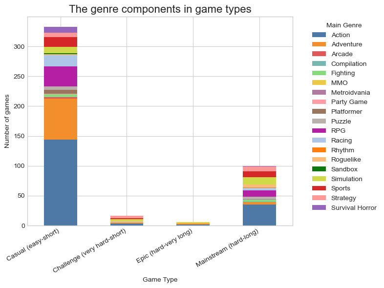

```python
# from cross tab, create a stacked bar
plt.style.use('seaborn-v0_8-whitegrid')
ax1 = crosstab.plot(kind = "bar", stacked = True,
              figsize=(8,6),
              color= palette1)

# setting labels and layout
plt.title("The genre components in game types", fontsize= 16)
plt.xticks(rotation =30, ha = 'right')
plt.xlabel("Game Type")
plt.ylabel("Number of games")
plt.legend(title = "Main Genre", bbox_to_anchor=(1.05,1), loc = 'upper left')
plt.tight_layout()
plt.show()
```

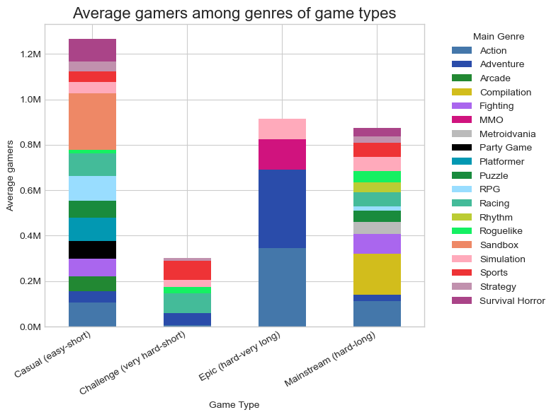

```python
from matplotlib.ticker import FuncFormatter
# create a stacked bar (average players in each genre by game type)
plt.style.use('seaborn-v0_8-whitegrid')
ax2 = gamer_vs_type.plot(kind = "bar", stacked = True,
              figsize=(8,6),
              color= tol21)

# change unit of gamers number in million unit
def mil_format(x, pos):
    return f'{x / 1_000_000:.1f}M'
ax2.yaxis.set_major_formatter(FuncFormatter(mil_format))

# setting labels and layout
plt.title("Average gamers among genres of game types", fontsize= 16)
plt.xticks(rotation =30, ha = 'right')
plt.xlabel("Game Type")
plt.ylabel("Average gamers")
plt.legend(title = "Main Genre",
           labels = gamer_vs_type.columns.get_level_values(1), # only take the second index in legend
           bbox_to_anchor=(1.05,1), # move legend to the right side of chart
           loc = 'upper left')
plt.tight_layout()
plt.show()
```

## Insight

Overall, the two charts show that Casual, Epic, and Mainstream are the three segments that players tend to prefer the most. Among them, the Casual segment stands out with the highest average number of gamers across genres. Notably, despite having fewer game genres, Epic records a remarkably large average user base, which even surpasses that of Mainstream. As a result, Epic represents a niche segment that Xbox Game Pass has not sufficiently exploited, as it attracts a large number of average gamers but still offers limited genre diversity.

Additionally, in the Mainstream segment, Compilation and Action attract larger average player bases than the other genres, while the segment overall is largely dominated by Action. Consequently, similar to Epic, this suggests that game development has been disproportionately focused on the Action genre, while neglecting other promising categories such as Compilation, which demonstrates a considerably higher average number of players compared to the rest.

# Conclusion

In conclusion, the main factors leveraging the success of gamer attraction on Xbox Game Pass are mass appeal (Sandbox) and high engagement (MMO and Compilation). Furthermore, deeper analysis using machine learning has also contributed significantly by identifying four main game types, ranging from Casual (quick entertainment) to Epic (hardcore, immersive experiences). Therefore, the key elements determining the success of a game do not solely depend on its genre, but also on the combination between genre and the experience it delivers to players (difficulty and playtime). Notably, completion ratio, as revealed through analysis, has shown that it is not a vital factor for popularity.

### Recommendation

Based on these insights, developers should adopt specific strategies aligned with their ultimate goals. For the mass market, greater attention should be directed toward freedom, creativity, and accessibility, as exemplified by Sandbox games. Meanwhile, building a loyal gamer community should focus on profound narratives, long-term content, and hardcore gameplay such as RPGs and MMOs. In terms of gaming experience, developers should also consider appropriate genre allocations within each game type to enhance diversity and better align with user preferences regarding expected difficulty and playtime.